# Risk Factor Analysis

## Outcome Variable

**Outcome Variable:** ever_co

## Predictor Variables

**Intervention Variable:** nrooms

**Adjustment Set:**

- arm
- sex
- W_mage
- meducyrs
- feducyrs
- hhwealth_quart
- hfoodsec
- W_mhtcm
- W_nchldlt5
- W_parity
- impfloor
- impsan
- safeh20
- delta_W_mage
- delta_meducyrs
- delta_feducyrs
- delta_hhwealth_quart
- delta_hfoodsec
- delta_W_mhtcm
- delta_W_nchldlt5
- delta_W_parity
- delta_impfloor
- delta_impsan
- delta_safeh20

## Stratifying Variables

The analysis was stratified on these variable(s):

- agecat
- studyid
- country

## Data Summary

| agecat | studyid | country | nrooms | ever_co | n_cell | n |
| --- | --- | --- | --- | --- | --- | --- |
| 0-24 months | ki0047075b-MAL-ED | BANGLADESH | 4+ | 0 | 10 | 242 |
| 0-24 months | ki0047075b-MAL-ED | BANGLADESH | 4+ | 1 | 2 | 242 |
| 0-24 months | ki0047075b-MAL-ED | BANGLADESH | 1 | 0 | 123 | 242 |
| 0-24 months | ki0047075b-MAL-ED | BANGLADESH | 1 | 1 | 29 | 242 |
| 0-24 months | ki0047075b-MAL-ED | BANGLADESH | 2 | 0 | 43 | 242 |
| 0-24 months | ki0047075b-MAL-ED | BANGLADESH | 2 | 1 | 7 | 242 |
| 0-24 months | ki0047075b-MAL-ED | BANGLADESH | 3 | 0 | 27 | 242 |
| 0-24 months | ki0047075b-MAL-ED | BANGLADESH | 3 | 1 | 1 | 242 |
| 0-24 months | ki0047075b-MAL-ED | BRAZIL | 4+ | 0 | 125 | 210 |
| 0-24 months | ki0047075b-MAL-ED | BRAZIL | 4+ | 1 | 2 | 210 |
| 0-24 months | ki0047075b-MAL-ED | BRAZIL | 1 | 0 | 4 | 210 |
| 0-24 months | ki0047075b-MAL-ED | BRAZIL | 1 | 1 | 0 | 210 |
| 0-24 months | ki0047075b-MAL-ED | BRAZIL | 2 | 0 | 20 | 210 |
| 0-24 months | ki0047075b-MAL-ED | BRAZIL | 2 | 1 | 0 | 210 |
| 0-24 months | ki0047075b-MAL-ED | BRAZIL | 3 | 0 | 59 | 210 |
| 0-24 months | ki0047075b-MAL-ED | BRAZIL | 3 | 1 | 0 | 210 |
| 0-24 months | ki0047075b-MAL-ED | INDIA | 4+ | 0 | 22 | 235 |
| 0-24 months | ki0047075b-MAL-ED | INDIA | 4+ | 1 | 3 | 235 |
| 0-24 months | ki0047075b-MAL-ED | INDIA | 1 | 0 | 66 | 235 |
| 0-24 months | ki0047075b-MAL-ED | INDIA | 1 | 1 | 18 | 235 |
| 0-24 months | ki0047075b-MAL-ED | INDIA | 2 | 0 | 54 | 235 |
| 0-24 months | ki0047075b-MAL-ED | INDIA | 2 | 1 | 24 | 235 |
| 0-24 months | ki0047075b-MAL-ED | INDIA | 3 | 0 | 40 | 235 |
| 0-24 months | ki0047075b-MAL-ED | INDIA | 3 | 1 | 8 | 235 |
| 0-24 months | ki0047075b-MAL-ED | NEPAL | 4+ | 0 | 122 | 236 |
| 0-24 months | ki0047075b-MAL-ED | NEPAL | 4+ | 1 | 9 | 236 |
| 0-24 months | ki0047075b-MAL-ED | NEPAL | 1 | 0 | 43 | 236 |
| 0-24 months | ki0047075b-MAL-ED | NEPAL | 1 | 1 | 9 | 236 |
| 0-24 months | ki0047075b-MAL-ED | NEPAL | 2 | 0 | 30 | 236 |
| 0-24 months | ki0047075b-MAL-ED | NEPAL | 2 | 1 | 1 | 236 |

[output cut: 354 more lines]

The following strata were considered:

- agecat: 0-24 months, studyid: ki0047075b-MAL-ED, country: BANGLADESH
- agecat: 0-24 months, studyid: ki0047075b-MAL-ED, country: BRAZIL
- agecat: 0-24 months, studyid: ki0047075b-MAL-ED, country: INDIA
- agecat: 0-24 months, studyid: ki0047075b-MAL-ED, country: NEPAL
- agecat: 0-24 months, studyid: ki0047075b-MAL-ED, country: PERU
- agecat: 0-24 months, studyid: ki0047075b-MAL-ED, country: SOUTH AFRICA
- agecat: 0-24 months, studyid: ki0047075b-MAL-ED, country: TANZANIA, UNITED REPUBLIC OF
- agecat: 0-24 months, studyid: ki1000108-CMC-V-BCS-2002, country: INDIA
- agecat: 0-24 months, studyid: ki1000108-IRC, country: INDIA
- agecat: 0-24 months, studyid: ki1017093b-PROVIDE, country: BANGLADESH
- agecat: 0-24 months, studyid: ki1017093c-NIH-Crypto, country: BANGLADESH
- agecat: 0-24 months, studyid: ki1113344-GMS-Nepal, country: NEPAL
- agecat: 0-24 months, studyid: ki1114097-CONTENT, country: PERU
- agecat: 0-24 months, studyid: ki1135781-COHORTS, country: INDIA
- agecat: 0-24 months, studyid: kiGH5241-JiVitA-3, country: BANGLADESH
- agecat: 0-24 months, studyid: kiGH5241-JiVitA-4, country: BANGLADESH
- agecat: 0-6 months, studyid: ki0047075b-MAL-ED, country: BANGLADESH
- agecat: 0-6 months, studyid: ki0047075b-MAL-ED, country: BRAZIL
- agecat: 0-6 months, studyid: ki0047075b-MAL-ED, country: INDIA
- agecat: 0-6 months, studyid: ki0047075b-MAL-ED, country: NEPAL
- agecat: 0-6 months, studyid: ki0047075b-MAL-ED, country: PERU
- agecat: 0-6 months, studyid: ki0047075b-MAL-ED, country: SOUTH AFRICA
- agecat: 0-6 months, studyid: ki0047075b-MAL-ED, country: TANZANIA, UNITED REPUBLIC OF
- agecat: 0-6 months, studyid: ki1000108-CMC-V-BCS-2002, country: INDIA
- agecat: 0-6 months, studyid: ki1000108-IRC, country: INDIA
- agecat: 0-6 months, studyid: ki1017093b-PROVIDE, country: BANGLADESH
- agecat: 0-6 months, studyid: ki1017093c-NIH-Crypto, country: BANGLADESH
- agecat: 0-6 months, studyid: ki1113344-GMS-Nepal, country: NEPAL
- agecat: 0-6 months, studyid: ki1114097-CONTENT, country: PERU
- agecat: 0-6 months, studyid: ki1135781-COHORTS, country: INDIA
- agecat: 0-6 months, studyid: kiGH5241-JiVitA-3, country: BANGLADESH
- agecat: 0-6 months, studyid: kiGH5241-JiVitA-4, country: BANGLADESH
- agecat: 6-24 months, studyid: ki0047075b-MAL-ED, country: BANGLADESH
- agecat: 6-24 months, studyid: ki0047075b-MAL-ED, country: BRAZIL
- agecat: 6-24 months, studyid: ki0047075b-MAL-ED, country: INDIA
- agecat: 6-24 months, studyid: ki0047075b-MAL-ED, country: NEPAL
- agecat: 6-24 months, studyid: ki0047075b-MAL-ED, country: PERU
- agecat: 6-24 months, studyid: ki0047075b-MAL-ED, country: SOUTH AFRICA
- agecat: 6-24 months, studyid: ki0047075b-MAL-ED, country: TANZANIA, UNITED REPUBLIC OF
- agecat: 6-24 months, studyid: ki1000108-CMC-V-BCS-2002, country: INDIA
- agecat: 6-24 months, studyid: ki1000108-IRC, country: INDIA
- agecat: 6-24 months, studyid: ki1017093b-PROVIDE, country: BANGLADESH
- agecat: 6-24 months, studyid: ki1017093c-NIH-Crypto, country: BANGLADESH
- agecat: 6-24 months, studyid: ki1113344-GMS-Nepal, country: NEPAL
- agecat: 6-24 months, studyid: ki1114097-CONTENT, country: PERU
- agecat: 6-24 months, studyid: ki1135781-COHORTS, country: INDIA
- agecat: 6-24 months, studyid: kiGH5241-JiVitA-3, country: BANGLADESH
- agecat: 6-24 months, studyid: kiGH5241-JiVitA-4, country: BANGLADESH

### Dropped Strata

Some strata were dropped due to rare outcomes:

- agecat: 0-24 months, studyid: ki0047075b-MAL-ED, country: BANGLADESH
- agecat: 0-24 months, studyid: ki0047075b-MAL-ED, country: BRAZIL
- agecat: 0-24 months, studyid: ki0047075b-MAL-ED, country: INDIA
- agecat: 0-24 months, studyid: ki0047075b-MAL-ED, country: NEPAL
- agecat: 0-24 months, studyid: ki0047075b-MAL-ED, country: PERU
- agecat: 0-24 months, studyid: ki0047075b-MAL-ED, country: SOUTH AFRICA
- agecat: 0-24 months, studyid: ki0047075b-MAL-ED, country: TANZANIA, UNITED REPUBLIC OF
- agecat: 0-24 months, studyid: ki1000108-CMC-V-BCS-2002, country: INDIA
- agecat: 0-24 months, studyid: ki1000108-IRC, country: INDIA
- agecat: 0-24 months, studyid: ki1017093b-PROVIDE, country: BANGLADESH
- agecat: 0-24 months, studyid: ki1114097-CONTENT, country: PERU
- agecat: 0-24 months, studyid: ki1135781-COHORTS, country: INDIA
- agecat: 0-6 months, studyid: ki0047075b-MAL-ED, country: BANGLADESH
- agecat: 0-6 months, studyid: ki0047075b-MAL-ED, country: BRAZIL
- agecat: 0-6 months, studyid: ki0047075b-MAL-ED, country: INDIA
- agecat: 0-6 months, studyid: ki0047075b-MAL-ED, country: NEPAL
- agecat: 0-6 months, studyid: ki0047075b-MAL-ED, country: PERU
- agecat: 0-6 months, studyid: ki0047075b-MAL-ED, country: SOUTH AFRICA
- agecat: 0-6 months, studyid: ki0047075b-MAL-ED, country: TANZANIA, UNITED REPUBLIC OF
- agecat: 0-6 months, studyid: ki1000108-CMC-V-BCS-2002, country: INDIA
- agecat: 0-6 months, studyid: ki1000108-IRC, country: INDIA
- agecat: 0-6 months, studyid: ki1017093b-PROVIDE, country: BANGLADESH
- agecat: 0-6 months, studyid: ki1017093c-NIH-Crypto, country: BANGLADESH
- agecat: 0-6 months, studyid: ki1113344-GMS-Nepal, country: NEPAL
- agecat: 0-6 months, studyid: ki1114097-CONTENT, country: PERU
- agecat: 0-6 months, studyid: ki1135781-COHORTS, country: INDIA
- agecat: 6-24 months, studyid: ki0047075b-MAL-ED, country: BANGLADESH
- agecat: 6-24 months, studyid: ki0047075b-MAL-ED, country: BRAZIL
- agecat: 6-24 months, studyid: ki0047075b-MAL-ED, country: INDIA
- agecat: 6-24 months, studyid: ki0047075b-MAL-ED, country: NEPAL
- agecat: 6-24 months, studyid: ki0047075b-MAL-ED, country: PERU
- agecat: 6-24 months, studyid: ki0047075b-MAL-ED, country: SOUTH AFRICA
- agecat: 6-24 months, studyid: ki0047075b-MAL-ED, country: TANZANIA, UNITED REPUBLIC OF
- agecat: 6-24 months, studyid: ki1000108-CMC-V-BCS-2002, country: INDIA
- agecat: 6-24 months, studyid: ki1000108-IRC, country: INDIA
- agecat: 6-24 months, studyid: ki1017093b-PROVIDE, country: BANGLADESH
- agecat: 6-24 months, studyid: ki1114097-CONTENT, country: PERU
- agecat: 6-24 months, studyid: ki1135781-COHORTS, country: INDIA

## Methods Detail

We’re interested in the causal parameters $E[Y_a]$ for all values of $a \in \mathcal{A}$. These parameters represent the mean outcome if, possibly contrary to fact, we intervened to set all units to have $A=a$. Under the randomization and positivity assumptions, these are identified by the statistical parameters $\psi_a=E_W[E_{Y|A,W}(Y|A=a,W)]$. In addition, we’re interested in the mean of $Y$, $E[Y]$ under no intervention (the observed mean). We will estimate these parameters by using SuperLearner to fit the relevant likelihood factors – $E_{Y|A,W}(Y|A=a,W)$ and $p(A=a|W)$, and then updating our likelihood fit using a joint TMLE.

For unadjusted analyses ($W=\{\}$), initial likelihoods were estimated using Lrnr_glm to estimate the simple $E(Y|A)$ and Lrnr_mean to estimate $p(A)$. For adjusted analyses, a small library containing Lrnr_glmnet, Lrnr_xgboost, and Lrnr_mean was used.

Having estimated these parameters, we will then use the delta method to estimate relative risks and attributable risks relative to a prespecified baseline level of $A$.

# Results Detail

## Results Plots

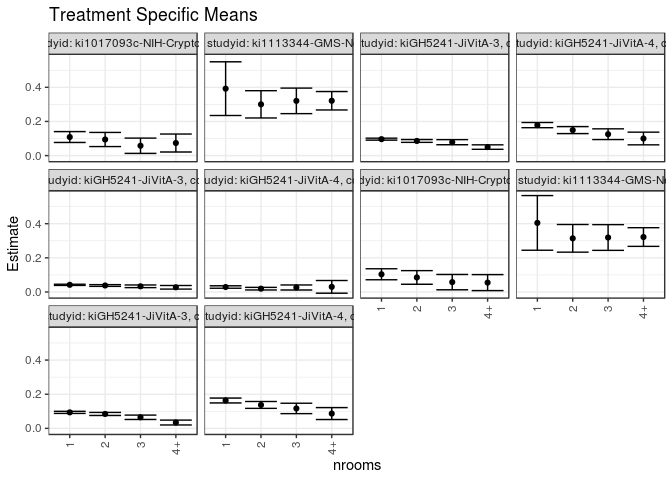

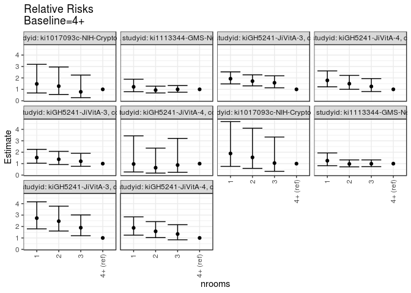

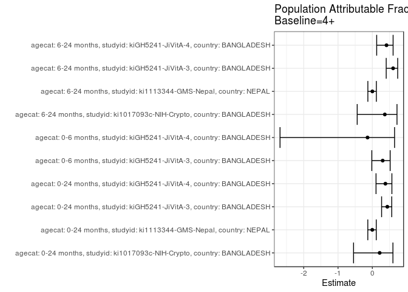

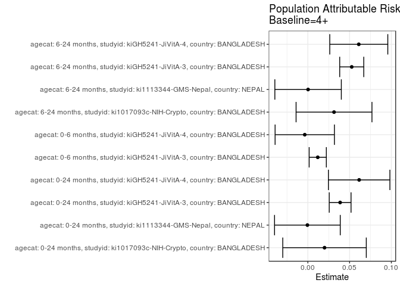

## Results Table

### Parameter: TSM

| agecat | studyid | country | intervention_level | baseline_level | estimate | ci_lower | ci_upper |
| --- | --- | --- | --- | --- | --- | --- | --- |
| 0-24 months | ki1017093c-NIH-Crypto | BANGLADESH | 4+ | NA | 0.0736842 | 0.0211140 | 0.1262544 |
| 0-24 months | ki1017093c-NIH-Crypto | BANGLADESH | 1 | NA | 0.1086957 | 0.0768735 | 0.1405178 |
| 0-24 months | ki1017093c-NIH-Crypto | BANGLADESH | 2 | NA | 0.0942408 | 0.0527794 | 0.1357022 |
| 0-24 months | ki1017093c-NIH-Crypto | BANGLADESH | 3 | NA | 0.0576923 | 0.0128515 | 0.1025331 |
| 0-24 months | ki1113344-GMS-Nepal | NEPAL | 4+ | NA | 0.3211238 | 0.2671025 | 0.3751451 |
| 0-24 months | ki1113344-GMS-Nepal | NEPAL | 1 | NA | 0.3920162 | 0.2347142 | 0.5493182 |
| 0-24 months | ki1113344-GMS-Nepal | NEPAL | 2 | NA | 0.3000801 | 0.2202398 | 0.3799204 |
| 0-24 months | ki1113344-GMS-Nepal | NEPAL | 3 | NA | 0.3204406 | 0.2456312 | 0.3952500 |
| 0-24 months | kiGH5241-JiVitA-3 | BANGLADESH | 4+ | NA | 0.0498466 | 0.0367521 | 0.0629410 |
| 0-24 months | kiGH5241-JiVitA-3 | BANGLADESH | 1 | NA | 0.0963178 | 0.0905393 | 0.1020962 |
| 0-24 months | kiGH5241-JiVitA-3 | BANGLADESH | 2 | NA | 0.0857640 | 0.0773960 | 0.0941320 |
| 0-24 months | kiGH5241-JiVitA-3 | BANGLADESH | 3 | NA | 0.0785120 | 0.0636402 | 0.0933838 |
| 0-24 months | kiGH5241-JiVitA-4 | BANGLADESH | 4+ | NA | 0.1000090 | 0.0629172 | 0.1371009 |
| 0-24 months | kiGH5241-JiVitA-4 | BANGLADESH | 1 | NA | 0.1785418 | 0.1633240 | 0.1937597 |
| 0-24 months | kiGH5241-JiVitA-4 | BANGLADESH | 2 | NA | 0.1492947 | 0.1287527 | 0.1698366 |
| 0-24 months | kiGH5241-JiVitA-4 | BANGLADESH | 3 | NA | 0.1252564 | 0.0938231 | 0.1566897 |
| 0-6 months | kiGH5241-JiVitA-3 | BANGLADESH | 4+ | NA | 0.0274715 | 0.0169754 | 0.0379677 |
| 0-6 months | kiGH5241-JiVitA-3 | BANGLADESH | 1 | NA | 0.0420216 | 0.0385408 | 0.0455023 |
| 0-6 months | kiGH5241-JiVitA-3 | BANGLADESH | 2 | NA | 0.0380049 | 0.0328954 | 0.0431143 |
| 0-6 months | kiGH5241-JiVitA-3 | BANGLADESH | 3 | NA | 0.0332181 | 0.0253656 | 0.0410706 |
| 0-6 months | kiGH5241-JiVitA-4 | BANGLADESH | 4+ | NA | 0.0300752 | -0.0071104 | 0.0672608 |
| 0-6 months | kiGH5241-JiVitA-4 | BANGLADESH | 1 | NA | 0.0290873 | 0.0219427 | 0.0362318 |
| 0-6 months | kiGH5241-JiVitA-4 | BANGLADESH | 2 | NA | 0.0193498 | 0.0117793 | 0.0269204 |
| 0-6 months | kiGH5241-JiVitA-4 | BANGLADESH | 3 | NA | 0.0264151 | 0.0116483 | 0.0411818 |
| 6-24 months | ki1017093c-NIH-Crypto | BANGLADESH | 4+ | NA | 0.0549451 | 0.0080942 | 0.1017960 |
| 6-24 months | ki1017093c-NIH-Crypto | BANGLADESH | 1 | NA | 0.1037464 | 0.0716406 | 0.1358522 |
| 6-24 months | ki1017093c-NIH-Crypto | BANGLADESH | 2 | NA | 0.0851064 | 0.0451917 | 0.1250211 |
| 6-24 months | ki1017093c-NIH-Crypto | BANGLADESH | 3 | NA | 0.0576923 | 0.0128504 | 0.1025342 |
| 6-24 months | ki1113344-GMS-Nepal | NEPAL | 4+ | NA | 0.3217338 | 0.2670804 | 0.3763872 |
| 6-24 months | ki1113344-GMS-Nepal | NEPAL | 1 | NA | 0.4045665 | 0.2445256 | 0.5646074 |
| 6-24 months | ki1113344-GMS-Nepal | NEPAL | 2 | NA | 0.3140686 | 0.2330579 | 0.3950793 |
| 6-24 months | ki1113344-GMS-Nepal | NEPAL | 3 | NA | 0.3190046 | 0.2436302 | 0.3943790 |
| 6-24 months | kiGH5241-JiVitA-3 | BANGLADESH | 4+ | NA | 0.0342538 | 0.0200324 | 0.0484753 |
| 6-24 months | kiGH5241-JiVitA-3 | BANGLADESH | 1 | NA | 0.0936743 | 0.0875813 | 0.0997673 |
| 6-24 months | kiGH5241-JiVitA-3 | BANGLADESH | 2 | NA | 0.0844545 | 0.0755953 | 0.0933137 |
| 6-24 months | kiGH5241-JiVitA-3 | BANGLADESH | 3 | NA | 0.0649555 | 0.0521633 | 0.0777478 |
| 6-24 months | kiGH5241-JiVitA-4 | BANGLADESH | 4+ | NA | 0.0867341 | 0.0517898 | 0.1216785 |
| 6-24 months | kiGH5241-JiVitA-4 | BANGLADESH | 1 | NA | 0.1632236 | 0.1489347 | 0.1775126 |
| 6-24 months | kiGH5241-JiVitA-4 | BANGLADESH | 2 | NA | 0.1371593 | 0.1170565 | 0.1572622 |
| 6-24 months | kiGH5241-JiVitA-4 | BANGLADESH | 3 | NA | 0.1167249 | 0.0861949 | 0.1472548 |

### Parameter: E(Y)

| agecat | studyid | country | intervention_level | baseline_level | estimate | ci_lower | ci_upper |
| --- | --- | --- | --- | --- | --- | --- | --- |
| 0-24 months | ki1017093c-NIH-Crypto | BANGLADESH | NA | NA | 0.0936675 | 0.0729118 | 0.1144233 |
| 0-24 months | ki1113344-GMS-Nepal | NEPAL | NA | NA | 0.3205980 | 0.2832855 | 0.3579105 |
| 0-24 months | kiGH5241-JiVitA-3 | BANGLADESH | NA | NA | 0.0885229 | 0.0846464 | 0.0923994 |
| 0-24 months | kiGH5241-JiVitA-4 | BANGLADESH | NA | NA | 0.1614449 | 0.1501252 | 0.1727646 |
| 0-6 months | kiGH5241-JiVitA-3 | BANGLADESH | NA | NA | 0.0393430 | 0.0368583 | 0.0418278 |
| 0-6 months | kiGH5241-JiVitA-4 | BANGLADESH | NA | NA | 0.0263831 | 0.0210411 | 0.0317252 |
| 6-24 months | ki1017093c-NIH-Crypto | BANGLADESH | NA | NA | 0.0863014 | 0.0659171 | 0.1066856 |
| 6-24 months | ki1113344-GMS-Nepal | NEPAL | NA | NA | 0.3220339 | 0.2842988 | 0.3597690 |
| 6-24 months | kiGH5241-JiVitA-3 | BANGLADESH | NA | NA | 0.0868080 | 0.0821483 | 0.0914677 |
| 6-24 months | kiGH5241-JiVitA-4 | BANGLADESH | NA | NA | 0.1477315 | 0.1371478 | 0.1583151 |

### Parameter: RR

| agecat | studyid | country | intervention_level | baseline_level | estimate | ci_lower | ci_upper |
| --- | --- | --- | --- | --- | --- | --- | --- |
| 0-24 months | ki1017093c-NIH-Crypto | BANGLADESH | 4+ | 4+ | 1.0000000 | 1.0000000 | 1.000000 |
| 0-24 months | ki1017093c-NIH-Crypto | BANGLADESH | 1 | 4+ | 1.4751553 | 0.6822075 | 3.189767 |
| 0-24 months | ki1017093c-NIH-Crypto | BANGLADESH | 2 | 4+ | 1.2789828 | 0.5531474 | 2.957254 |
| 0-24 months | ki1017093c-NIH-Crypto | BANGLADESH | 3 | 4+ | 0.7829670 | 0.2726112 | 2.248761 |
| 0-24 months | ki1113344-GMS-Nepal | NEPAL | 4+ | 4+ | 1.0000000 | 1.0000000 | 1.000000 |
| 0-24 months | ki1113344-GMS-Nepal | NEPAL | 1 | 4+ | 1.2207637 | 0.7900928 | 1.886189 |
| 0-24 months | ki1113344-GMS-Nepal | NEPAL | 2 | 4+ | 0.9344687 | 0.6827020 | 1.279082 |
| 0-24 months | ki1113344-GMS-Nepal | NEPAL | 3 | 4+ | 0.9978726 | 0.7486975 | 1.329976 |
| 0-24 months | kiGH5241-JiVitA-3 | BANGLADESH | 4+ | 4+ | 1.0000000 | 1.0000000 | 1.000000 |
| 0-24 months | kiGH5241-JiVitA-3 | BANGLADESH | 1 | 4+ | 1.9322851 | 1.4761652 | 2.529341 |
| 0-24 months | kiGH5241-JiVitA-3 | BANGLADESH | 2 | 4+ | 1.7205603 | 1.3045291 | 2.269269 |
| 0-24 months | kiGH5241-JiVitA-3 | BANGLADESH | 3 | 4+ | 1.5750737 | 1.1349184 | 2.185935 |
| 0-24 months | kiGH5241-JiVitA-4 | BANGLADESH | 4+ | 4+ | 1.0000000 | 1.0000000 | 1.000000 |
| 0-24 months | kiGH5241-JiVitA-4 | BANGLADESH | 1 | 4+ | 1.7852574 | 1.2198926 | 2.612643 |
| 0-24 months | kiGH5241-JiVitA-4 | BANGLADESH | 2 | 4+ | 1.4928118 | 1.0032268 | 2.221319 |
| 0-24 months | kiGH5241-JiVitA-4 | BANGLADESH | 3 | 4+ | 1.2524510 | 0.8080955 | 1.941149 |
| 0-6 months | kiGH5241-JiVitA-3 | BANGLADESH | 4+ | 4+ | 1.0000000 | 1.0000000 | 1.000000 |
| 0-6 months | kiGH5241-JiVitA-3 | BANGLADESH | 1 | 4+ | 1.5296395 | 1.0391952 | 2.251547 |
| 0-6 months | kiGH5241-JiVitA-3 | BANGLADESH | 2 | 4+ | 1.3834268 | 0.9222080 | 2.075312 |
| 0-6 months | kiGH5241-JiVitA-3 | BANGLADESH | 3 | 4+ | 1.2091832 | 0.7683664 | 1.902899 |
| 0-6 months | kiGH5241-JiVitA-4 | BANGLADESH | 4+ | 4+ | 1.0000000 | 1.0000000 | 1.000000 |
| 0-6 months | kiGH5241-JiVitA-4 | BANGLADESH | 1 | 4+ | 0.9671515 | 0.2726685 | 3.430473 |
| 0-6 months | kiGH5241-JiVitA-4 | BANGLADESH | 2 | 4+ | 0.6433824 | 0.1753735 | 2.360339 |
| 0-6 months | kiGH5241-JiVitA-4 | BANGLADESH | 3 | 4+ | 0.8783019 | 0.2404209 | 3.208598 |
| 6-24 months | ki1017093c-NIH-Crypto | BANGLADESH | 4+ | 4+ | 1.0000000 | 1.0000000 | 1.000000 |
| 6-24 months | ki1017093c-NIH-Crypto | BANGLADESH | 1 | 4+ | 1.8881844 | 0.7622425 | 4.677305 |
| 6-24 months | ki1017093c-NIH-Crypto | BANGLADESH | 2 | 4+ | 1.5489362 | 0.5853251 | 4.098924 |
| 6-24 months | ki1017093c-NIH-Crypto | BANGLADESH | 3 | 4+ | 1.0500000 | 0.3312144 | 3.328660 |
| 6-24 months | ki1113344-GMS-Nepal | NEPAL | 4+ | 4+ | 1.0000000 | 1.0000000 | 1.000000 |
| 6-24 months | ki1113344-GMS-Nepal | NEPAL | 1 | 4+ | 1.2574574 | 0.8171646 | 1.934983 |
| 6-24 months | ki1113344-GMS-Nepal | NEPAL | 2 | 4+ | 0.9761753 | 0.7173505 | 1.328386 |
| 6-24 months | ki1113344-GMS-Nepal | NEPAL | 3 | 4+ | 0.9915172 | 0.7408976 | 1.326913 |
| 6-24 months | kiGH5241-JiVitA-3 | BANGLADESH | 4+ | 4+ | 1.0000000 | 1.0000000 | 1.000000 |
| 6-24 months | kiGH5241-JiVitA-3 | BANGLADESH | 1 | 4+ | 2.7347097 | 1.7968532 | 4.162075 |
| 6-24 months | kiGH5241-JiVitA-3 | BANGLADESH | 2 | 4+ | 2.4655502 | 1.6063323 | 3.784359 |
| 6-24 months | kiGH5241-JiVitA-3 | BANGLADESH | 3 | 4+ | 1.8963006 | 1.1936447 | 3.012585 |
| 6-24 months | kiGH5241-JiVitA-4 | BANGLADESH | 4+ | 4+ | 1.0000000 | 1.0000000 | 1.000000 |
| 6-24 months | kiGH5241-JiVitA-4 | BANGLADESH | 1 | 4+ | 1.8818848 | 1.2453302 | 2.843816 |
| 6-24 months | kiGH5241-JiVitA-4 | BANGLADESH | 2 | 4+ | 1.5813768 | 1.0295001 | 2.429094 |
| 6-24 months | kiGH5241-JiVitA-4 | BANGLADESH | 3 | 4+ | 1.3457777 | 0.8377712 | 2.161828 |

### Parameter: PAR

| agecat | studyid | country | intervention_level | baseline_level | estimate | ci_lower | ci_upper |
| --- | --- | --- | --- | --- | --- | --- | --- |
| 0-24 months | ki1017093c-NIH-Crypto | BANGLADESH | 4+ | NA | 0.0199833 | -0.0300336 | 0.0700003 |
| 0-24 months | ki1113344-GMS-Nepal | NEPAL | 4+ | NA | -0.0005258 | -0.0398709 | 0.0388194 |
| 0-24 months | kiGH5241-JiVitA-3 | BANGLADESH | 4+ | NA | 0.0386763 | 0.0256265 | 0.0517261 |
| 0-24 months | kiGH5241-JiVitA-4 | BANGLADESH | 4+ | NA | 0.0614359 | 0.0246330 | 0.0982388 |
| 0-6 months | kiGH5241-JiVitA-3 | BANGLADESH | 4+ | NA | 0.0118715 | 0.0015894 | 0.0221536 |
| 0-6 months | kiGH5241-JiVitA-4 | BANGLADESH | 4+ | NA | -0.0036920 | -0.0391994 | 0.0318154 |
| 6-24 months | ki1017093c-NIH-Crypto | BANGLADESH | 4+ | NA | 0.0313563 | -0.0140670 | 0.0767796 |
| 6-24 months | ki1113344-GMS-Nepal | NEPAL | 4+ | NA | 0.0003001 | -0.0394998 | 0.0401000 |
| 6-24 months | kiGH5241-JiVitA-3 | BANGLADESH | 4+ | NA | 0.0525541 | 0.0381571 | 0.0669512 |
| 6-24 months | kiGH5241-JiVitA-4 | BANGLADESH | 4+ | NA | 0.0609973 | 0.0262478 | 0.0957469 |

### Parameter: PAF

| agecat | studyid | country | intervention_level | baseline_level | estimate | ci_lower | ci_upper |
| --- | --- | --- | --- | --- | --- | --- | --- |
| 0-24 months | ki1017093c-NIH-Crypto | BANGLADESH | 4+ | NA | 0.2133432 | -0.5474483 | 0.6000972 |
| 0-24 months | ki1113344-GMS-Nepal | NEPAL | 4+ | NA | -0.0016399 | -0.1322010 | 0.1138654 |
| 0-24 months | kiGH5241-JiVitA-3 | BANGLADESH | 4+ | NA | 0.4369076 | 0.2701920 | 0.5655391 |
| 0-24 months | kiGH5241-JiVitA-4 | BANGLADESH | 4+ | NA | 0.3805377 | 0.1076702 | 0.5699644 |
| 0-6 months | kiGH5241-JiVitA-3 | BANGLADESH | 4+ | NA | 0.3017431 | -0.0153018 | 0.5197855 |
| 0-6 months | kiGH5241-JiVitA-4 | BANGLADESH | 4+ | NA | -0.1399394 | -2.6903450 | 0.6478752 |
| 6-24 months | ki1017093c-NIH-Crypto | BANGLADESH | 4+ | NA | 0.3633351 | -0.4411875 | 0.7187443 |
| 6-24 months | ki1113344-GMS-Nepal | NEPAL | 4+ | NA | 0.0009319 | -0.1306260 | 0.1171820 |
| 6-24 months | kiGH5241-JiVitA-3 | BANGLADESH | 4+ | NA | 0.6054069 | 0.4043032 | 0.7386192 |
| 6-24 months | kiGH5241-JiVitA-4 | BANGLADESH | 4+ | NA | 0.4128934 | 0.1267166 | 0.6052894 |